# K Means Application: Data Science Capstone

Author

Lindsay Guyette, Alondra Nunez, Chantal Ojurongbe, Jonathan Broada

Published

August 6, 2024

[Presentation](https://ldg27uwf.github.io/STA6257_Project_K_means/slides.html#/title-slide)

## Introduction

The objectives of this review are threefold: to provide a comprehensive overview of K-means clustering, to discuss its methodology, applications, and advancements, and to identify the challenges and future research directions. In this literature review, we aim to give an in-depth analysis of K-means clustering, examine its various aspects and practical uses, and highlight the current challenges along with potential areas for future research.

Clustering is the process of grouping similar objects or data points together based on their characteristics or attributes. Clustering is an unsupervised learning technique employed in data mining and machine learning to categorize a collection of items based on their similarity. The goal is to create groupings, or clusters, where objects within the same cluster are more alike to each other than to objects in other clusters. Clustering aims to identify inherent clusters in a dataset where the data points within each cluster exhibit a strong resemblance, yet the clusters themselves are clearly dissimilar from one another.

The similarity of data points is commonly assessed using a distance metric, such as Euclidean distance, Manhattan distance, or cosine similarity. The choice of metric depends on the characteristics of the data and the specific clustering technique employed (Berkhin 2006).

The term “k-Means Clustering” refers to a method used in data analysis and machine learning to partition a set of data points into k distinct clusters. k-Means clustering is a highly popular and extensively utilized approach for clustering. The objective is to divide a dataset into k clusters, where k is a predetermined number of clusters. The method operates in an iterative manner, assigning each data point to one of k clusters based on the given attributes. The main concept is to establish k centroids, representing each cluster, and allocate each data point to the centroid that is closest to it. This allocation is done in a way that minimizes the total squared distances between the data points and their respective centroids.

K-means clustering can be applied to a wide variety of data, including bioinformatics, sociology, and in food markets.

**Bioinformatics** refers to the usage of analytical techniques to interpret different types of biological data. These datasets can be large or small, containing information about genomic sequences, gene expression, and protein expression, among other biological characteristics. This information can then be used to draw conclusions about basic biological processes, disease states, and gene therapies, among other applications (Bayat 2002). K-means clustering is one type of data analysis technique that can be used to group differential gene/protein expression according to specific phenotypes, or physical presentations of biological traits. For instance, this can be used to assign cells to specific types based on single-cell RNA sequencing data, which measures the total gene expression for thousands of genes within a single cell. Yang et al., 2017 utilized k-means clustering to analyze the scRNA sequencing data of hundreds of cell types to develop a novel algorithm that identifies the optimal sets of genes to cluster single cells into distinct biological groups.

Additionally, k-means clustering can be applied to population-level data to determine significant groupings related to **socioeconomic outcomes.** The factors related to socioeconomic mobility were evaluated in a 2023 study using longitudinal data from the Opportunity Atlas project. Here, k-means clustering revealed differences in socioeconomic mobility related to geographic location, income, and neighborhood factors such as poverty rate and incarceration rates (Zelasky et al. 2023).

In 2017, food market researchers used k-means clustering to segment the organic food market in Lebanon. By starting with 13 variables, they applied Principal Component Analysis (PCA) to reduce the number while retaining the explanatory power. The k-means algorithm was then employed, resulting in four distinct clusters of consumer opinions on organic food. Each cluster was labeled appropriately to facilitate understanding and application in research. The outcomes present relevant groups that can guide policy and initiatives in the organic food market in Lebanon (Tleis, Callieris, and Roma 2017).

Variations and enhancements of the k-means clustering algorithm have been thoroughly researched. The k-means algorithm was originally proposed in in the 1950s and due to its computational simplicity, it has many challenges (like having to select the number of clusters, or minimal local convergence because of the random initial centroids) many variants of k-means have been created to tackle those challenges and broaden the applicability of k-means (Ikotun et al. 2023).

One such issue is the selection of the number of clusters in k-means clustering. In a 2013 review, researcher Kodinariya explains how to estimate the number of clusters. Fields across the board use clustering so there is no one answer on how many clusters to use. Kodinariya explores six different ways on how to determine the best number of clusters. The six methods are: rule of thumb, elbow method, information criterion approach, information theoretic approach, Silhouette, and cross validation. Kodinariya explains how no size fits all and will depend on the context of the data. The elbow method is the oldest and most used method but information theoretic approach is more rigorous. It is best to use more than one method to estimate the best number of clusters (Kodinariya and Makwana 2013).

Yang et al propose a new method on selecting the optimal k value by addressing both application-specific and detector-specific factors. The authors proposed the KFC method which offers a parameter free solution with linear time complexity. Yang et al made the KFC method available at www.outliernet.com to an external site to facilitate reproducibility and provide opportunities for others to expand their research. Their research showed that the KFC method outperforms traditional methods and is much more versatile making it useful across many fields (Yang, Tan, and Rahardja 2023).

The article “K-means clustering with outlier removal” by Guojun Gan and Michael Kwok-Po Ng proposes to improve the k-means clustering algorithm by including outlier detection. The KMOR (k-means with outlier removal) algorithm broadens the classic k-means algorithm by proposing an additional cluster for outliers. The methodology comprises initialization, objective function optimization, iterative process updates, convergence, and parameter control. The KMOR algorithm was tested on synthetic and real datasets. It showed remarkable performance in overall clustering accuracy and outlier detection. Moreover, compared to other established algorithms such as ODC (Outlier Detection and clustering), k-means, and NEO-k-means algorithms, results have confirmed that KMOR algorithms not only outperformed them but also consistently cluster data and detect outliers with precision simultaneously. The KMOR algorithm’s ability to seamlessly integrate clustering and outlier detection for both synthetic and real datasets showcased its dominance over current methods in terms of accuracy and efficiency. Futuristically, the goals are to investigate diverse ways to control outliers by refining parameter selection and broadening the algorithm for subspace clustering (Gan and Ng 2017).

## Methods

The k-means clustering algorithm can be analytically defined as an optimization problem. The objective is to divide a collection of n data points into k clusters in a manner that minimizes the sum of squares inside each cluster (WCSS). The process entails the following steps: Objective function (minimization of within-cluster variance). The goal of k-means is to minimize the total sum of squared distances between each data point and its corresponding cluster centroid. The **within-cluster sum of squares (WCSS)** represents this.

$$\text{WCSS} = \sum_{j=1}^{k}\sum_{xi\in Cj}^{} \left\| x_{i} - \mu_{j} \right\|^2$$

where: C<sub>j</sub> is the set of data points assigned to cluster j, x<sub>i</sub> is a data point, μ<sub>j</sub> is the centroid of cluster j, ∥x<sub>i</sub>−μ<sub>j</sub>∥ is the Euclidean distance between data point x<sub>i</sub> and centroid μ<sub>j</sub>. Mathematical representation of the algorithm. Algorithm Steps in Mathematical Terms Initialization Randomly choose k initial centroids μ<sub>1</sub>,μ<sub>2</sub>,…,μ<sub>k</sub> from the dataset {x<sub>1</sub>,x<sub>2</sub>,…,x<sub>n</sub>}. Assignment Step Assign each data point x<sub>i</sub> to the nearest centroid μ<sub>j</sub>. This can be mathematically expressed as: C<sub>j</sub> = {x<sub>i</sub> : ∥x<sub>i</sub>−μ<sub>j</sub>∥2 ≤ ∥x<sub>i</sub>−μ<sub>l</sub>∥2 for all l, 1 ≤ l ≤ k} Here, C<sub>j</sub> denotes the set of points assigned to centroid μ<sub>j</sub> (Hastie, Tibshirani, and Friedman 2009).

The k-means clustering algorithm is an iterative procedure that involves two steps: allocating data points to clusters and updating the cluster centroids. Below is a comprehensive breakdown of the sequential steps in the algorithm:

Initialization of centroids. Random initialization selects 𝑘 initial centroids at random from the dataset. Every centroid corresponds to the original center of a cluster. The algorithm being referred to is called “k-means++” is a refined technique that distributes the initial centroids in order to enhance the performance of the algorithm. The initial centroid is selected at random, whereas the following centroids are chosen according to a probability that is directly proportionate to their distance from the nearest existing centroid. Assignment of data points to nearest centroids. Compute the distance from each data point to every centroid. Popular distance measurements include Euclidean distance, Manhattan distance, and cosine similarity. Allocate each data point to the cluster that has the closest centroid to it. This results in the formation of 𝑘 clusters, where each data point is assigned to a single cluster. Update of centroids. Determine the updated centroid of each cluster by computing the average of all data points assigned to that cluster. The updated centroid is calculated as the average position of the data points within the cluster. This update step recalibrates the position of the centroids to more accurately reflect the clusters produced in the assignment stage. Iteration until convergence. Iterate the assignment and update processes until the centroids exhibit minimal variation between iterations. Convergence is usually assessed by verifying if the positions of the centroids have reached a stable state within a predetermined tolerance threshold. Alternatively, the process can be halted after reaching a predetermined number of iterations if convergence is not attained prior to that.

Inertia is referred to as within-cluster sum of squares, quantifying the effectiveness of cluster formation. Smaller inertia values suggest superior clustering performance.The k-means method continues to iterate until it reaches convergence, which is when the centroids stop changing considerably. This indicates that the clusters have become stable. Iterate the assignment and update stages until the centroids exhibit minimal changes, suggesting that the algorithm has reached convergence. Convergence is determined by setting a threshold ϵ to measure the change in centroids: ||μj(t+1)-μj(t)||<ϵ for all j, 1≤ j ≤ k where μj(t) and μj(t+1) are the centroids of cluster j at iterations t and t+1. Distance Metrics deals with the similarity of data points that is commonly assessed using a distance metric, such as Euclidean distance.The distance measure employed in k-means is the Euclidean distance, computed as:

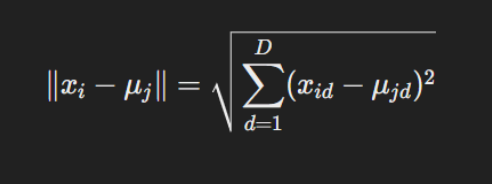

where: 𝑥𝑖𝑑 is the 𝑑-th dimension of data point 𝑥𝑖, 𝜇𝑗𝑑 is the 𝑑-th dimension of centroid 𝜇𝑗, 𝐷 is the number of dimensions of the data points (Xu, R., & Wunsch, D., 2005). The algorithm of k-Means clustering includes the following steps. First initialization; select 𝑘 initial centroids either randomly or using a more advanced technique like k-means++. Then assignment Step; allocate each data point to the closest centroid using the selected distance metric. Compute the updated centroids by averaging all the data points allocated to each centroid. Repeatedly perform the assignment and update processes until either the centroids do not change appreciably (convergence) or a maximum number of iterations is reached. The highest number of iterations that the algorithm will execute if it has not achieved convergence before reaching this limit. The algorithm reaches convergence when there is no significant change in the centroids between iterations. The displacement of centroids can be quantified by employing a predetermined threshold ϵ:

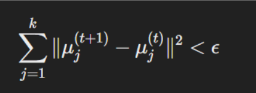

On the other hand, the method can be terminated after reaching a predetermined number of iterations, regardless of whether the centroids have fully stabilized (Xu, R., & Wunsch, D., 2005). A criterion used to establish when convergence has been achieved. The algorithm terminates if the difference between the centroids is below the specified tolerance.

After importing the dataset, the expression for 77 proteins data are scaled and analyzed using Principle Component Analysis to reduce the number of dimensions. Then, the optimal number of clusters is determined using the elbow method, silhouette analysis, and gap statistic.The data are then analyzed using the k-means algorithm with the default euclidean distance metric. Differences are then considered using a contingency table and heat map to identify similar and dissimilar groups. These cluster assignments are then plotted against class to visually identify cluster characteristics.

## Data Analysis

### Load Necessary Libraries

```r
#install.packages("NbClust")
#install.packages("fpc")
#install.packages("tidyverse")
#install.packages("factoextra")
#install.packages("cluster")
#install.packages("pheatmap")
#install.packages("plotly")
#install.packages("caret")
#install.packages("e1071")
#install.packages("glmnet")

library(fpc)
library(NbClust)
library(cluster)
library(tidyverse)
library(factoextra)
library(pheatmap)
library(dplyr)
library(plotly)
library(ggplot2)
library(caret)
library(e1071)
library(glmnet)
```

### Load the data

```r
data <- read.csv("mice_new_jonathan.csv")

color_palette <- c(
  "c-CS-s" = "#f54545",
  "c-CS-m" = "#ff8787",
  "c-SC-s" = "#ffa538",
  "c-SC-m" = "#ffcf94",
  "t-CS-s" = "#4f9ed4",
  "t-CS-m" = "#133a62",
  "t-SC-s" = "#6fbf67",
  "t-SC-m" = "#1a501d"
)
```

```r
# Load necessary libraries
library(dplyr)
library(tidyr)
library(knitr)
library(kableExtra)


# Select the first 6 columns and the last 6 columns
selected_columns <- data %>%
  select(1:6, (ncol(data)-5):ncol(data))

# Display the first few rows of the dataset
data_head <- head(selected_columns)

# Print the head of the dataset table with styling
data_head %>%
  kable(caption = "First Few Rows of the Mice Data") %>%
  kable_styling(bootstrap_options = c("striped", "hover", "condensed"),
                full_width = TRUE,
                position = "left") %>%
  scroll_box(width = "1000px", height = "400px")
```

First Few Rows of the Mice Data

| MouseID | Protein_1 | Protein_2 | Protein_3 | Protein_4 | Protein_5 | Protein_77 | Genotype | Treatment | Behavior | class | class_short |
| --- | --- | --- | --- | --- | --- | --- | --- | --- | --- | --- | --- |
| 3415_1 | 0.6497813 | 0.8286964 | 0.4058618 | 2.921435 | 5.167979 | 1.627181 | Control | Memantine | CS | Control Training Memantine | c-CS-m |
| 3415_2 | 0.6164807 | 0.8419742 | 0.3885837 | 2.862575 | 5.194163 | 1.562096 | Control | Memantine | CS | Control Training Memantine | c-CS-m |
| 3415_3 | 0.6374243 | 0.8528818 | 0.4005615 | 2.968155 | 5.350820 | 1.571868 | Control | Memantine | CS | Control Training Memantine | c-CS-m |
| 3415_4 | 0.5768145 | 0.7553900 | 0.3483463 | 2.624901 | 4.727509 | 1.646608 | Control | Memantine | CS | Control Training Memantine | c-CS-m |
| 3415_5 | 0.5425448 | 0.7579173 | 0.3500507 | 2.634509 | 4.735602 | 1.607631 | Control | Memantine | CS | Control Training Memantine | c-CS-m |
| 3415_6 | 0.5699176 | 0.7610777 | 0.3439100 | 2.598085 | 4.764640 | 1.506520 | Control | Memantine | CS | Control Training Memantine | c-CS-m |

```r
# Count occurrences for class_short
class_short_counts <- data %>%
  count(class_short) %>%
  rename(Count = n)

# Print the class_short counts table with styling
class_short_counts %>%
  kable() %>%
  kable_styling(bootstrap_options = c("striped", "hover", "condensed"),
                full_width = TRUE,
                position = "left") %>%
  add_header_above(c("Class Short Counts" = 2))
```

| Class Short Counts class_short | Class Short Counts Count |
| --- | --- |
| c-CS-m | 45 |
| c-CS-s | 75 |
| c-SC-m | 60 |
| c-SC-s | 75 |
| t-CS-m | 90 |
| t-CS-s | 75 |
| t-SC-m | 60 |
| t-SC-s | 72 |

```r
# Count occurrences for Behavior
behavior_counts <- data %>%
  count(Behavior) %>%
  rename(Count = n)

# Count occurrences for Genotype
genotype_counts <- data %>%
  count(Genotype) %>%
  rename(Count = n)

# Count occurrences for Treatment
treatment_counts <- data %>%
  count(Treatment) %>%
  rename(Count = n)

# Add a new column to each table to indicate the category
behavior_counts <- behavior_counts %>%
  mutate(Category = "Behavior")

genotype_counts <- genotype_counts %>%
  mutate(Category = "Genotype")

treatment_counts <- treatment_counts %>%
  mutate(Category = "Treatment")

# Rename 'Behavior', 'Genotype', and 'Treatment' columns to a generic 'Type' column for uniformity
behavior_counts <- behavior_counts %>%
  rename(Type = Behavior)

genotype_counts <- genotype_counts %>%
  rename(Type = Genotype)

treatment_counts <- treatment_counts %>%
  rename(Type = Treatment)

# Combine the three tables
combined_counts <- bind_rows(behavior_counts, genotype_counts, treatment_counts)

# Print the combined table
combined_counts %>%
  kable() %>%
  kable_styling(bootstrap_options = c("striped", "hover", "condensed"),
                full_width = TRUE,
                position = "left")
```

| Type | Count | Category |
| --- | --- | --- |
| CS | 285 | Behavior |
| SC | 267 | Behavior |
| Control | 255 | Genotype |
| Ts65Dn | 297 | Genotype |
| Memantine | 255 | Treatment |
| Saline | 297 | Treatment |

```r
# Calculate summary statistics for Protein_33 by class_short
summary_stats_protein_33 <- data %>%
  group_by(class_short) %>%
  summarise(
    Mean = mean(Protein_33, na.rm = TRUE),
    Median = median(Protein_33, na.rm = TRUE),
    SD = sd(Protein_33, na.rm = TRUE)
  )

# Print the summary statistics table with styling
summary_stats_protein_33 %>%
  kable(caption = "Summary Statistics for Protein_33 by class_short") %>%
  kable_styling(bootstrap_options = c("striped", "hover", "condensed"),
                full_width = TRUE,
                position = "left")
```

Summary Statistics for Protein_33 by class_short

| class_short | Mean | Median | SD |
| --- | --- | --- | --- |
| c-CS-m | 0.3046572 | 0.3047206 | 0.0345969 |
| c-CS-s | 0.2984724 | 0.2908857 | 0.0393513 |
| c-SC-m | 0.6161882 | 0.6072476 | 0.1050420 |
| c-SC-s | 0.9179574 | 0.9021220 | 0.1793247 |
| t-CS-m | 0.3137553 | 0.3152210 | 0.0343619 |
| t-CS-s | 0.3123844 | 0.3052201 | 0.0311609 |
| t-SC-m | 0.7789642 | 0.7063120 | 0.2446683 |
| t-SC-s | 0.7107764 | 0.6204388 | 0.2671747 |

## Feature Selection Functions

```r
### All Features
feature_selection_all <- function(data) {
  protein_data <- data[, 2:78]
  protein_data_scaled <- scale(protein_data)
  return(protein_data_scaled)
}


### Hand Selection
feature_selection_hand <- function(data) {
  protein_data <- data %>%  select(Protein_1, Protein_2, Protein_8, Protein_11, Protein_18, Protein_21, Protein_33, Protein_35, Protein_51, Protein_57, Protein_61, Protein_71, Protein_77)
  protein_data_scaled <- scale(protein_data)
  return(protein_data_scaled)
}

### Variance
feature_selection_variance <- function(data, variance_threshold = 1) {
  protein_data <- data[, 2:78]
  protein_data_scaled <- scale(protein_data)

  # Calculate variance for each feature
  variances <- apply(protein_data_scaled, 2, var)

  # Select features with variance above the threshold
  selected_features <- names(variances[variances > variance_threshold])
  protein_data_scaled <- protein_data_scaled[, selected_features]
  return(protein_data_scaled)
}

### RFE
feature_selection_rfe <- function(data) {
  protein_data <- data[, 2:78]
  class_labels <- as.factor(data$class_short)

  # Create control function for RFE
  control <- rfeControl(functions = rfFuncs, method = "cv", number = 10)

  # Run RFE algorithm
  set.seed(123)
  rfe_result <- rfe(protein_data, class_labels, sizes = c(1:20), rfeControl = control)

  # Get the selected features
  selected_features <- predictors(rfe_result)
  protein_data_selected <- protein_data[, selected_features]
  protein_data_scaled <- scale(protein_data_selected)
  return(protein_data_scaled)
}

### Lasso
feature_selection_lasso <- function(data) {
  protein_data <- data[, 2:78]
  protein_data_scaled <- scale(protein_data)

  # Define the feature matrix (X) and the response vector (y)
  X <- as.matrix(protein_data_scaled)

  # Ensure the response variable is a factor
  y <- as.factor(data$class_short)

  # Apply Lasso using glmnet
  set.seed(123)  # For reproducibility
  lasso_model <- cv.glmnet(X, y, alpha = 1, family = "multinomial")

  # Get the coefficients of the best model
  coef_lasso <- coef(lasso_model, s = "lambda.min")

  # Extract the selected features (non-zero coefficients)
  selected_features_matrix <- as.matrix(coef_lasso[[1]])
  selected_features <- rownames(selected_features_matrix)[selected_features_matrix != 0]
  selected_features <- selected_features[!(selected_features %in% "(Intercept)")]

  # Create a new dataframe with selected features
  important_features <- protein_data[, selected_features]

  # Scale the important features data
  protein_data_scaled <- scale(important_features)
  return(protein_data_scaled)
}
```

## PCA and K-Means Functions

```r
run_pca_kmeans <- function(data, pca_dimensions, number_of_clusters) {
  pca_result <- prcomp(data, center = TRUE, scale. = TRUE)
  pca_data <- pca_result$x[, 1:pca_dimensions]

  kmeans_result <- kmeans(pca_data, centers = number_of_clusters, nstart = 100)

  return(list(pca_data = pca_data, kmeans_result = kmeans_result))
}
```

## Visualizations Functions

```r
visualizations <- function(data, selected_features, pca_data, kmeans_result, color_palette) {
  # Add the cluster assignments to the original data
  data$cluster <- as.factor(kmeans_result$cluster)

  # Create a data frame with PCA results and class information
  pca_data2 <- data.frame(pca_data, class_short = data$class_short, cluster = data$cluster)

  # Visualize Clusters
  cluster_plot <- fviz_cluster(kmeans_result, data = selected_features, ellipse.type="convex", geom = "point") + theme_minimal()

  # Plotting using ggplot2
  pca_plot <- ggplot(pca_data2, aes(x = PC1, y = PC2, color = class_short)) +
    geom_point() +
    stat_ellipse(aes(group = cluster), type = "norm") +  # Here you can use 'cluster' to draw ellipses around clusters
    theme_minimal() +
    scale_color_manual(values = color_palette) +  # Apply the custom color palette
    labs(color = "Class")  # Customize legend title

  # Plot cluster assignments against the original classes
  cluster_assignment_plot <- ggplot(data, aes(x = cluster, fill = class_short)) +
    geom_bar(position = "stack") +
    scale_fill_manual(values = color_palette) +
    theme(axis.text.x = element_text(angle = 90, hjust = 1)) +
    labs(title = "Cluster Assignments by Class",
         x = "Cluster",
         y = "Count",
         fill = "Class")

  return(list(cluster_plot = cluster_plot, pca_plot = pca_plot, cluster_assignment_plot = cluster_assignment_plot))
}
```

# Comparison of parameters/methods

## Feature Selection

We are testing 4 methods: 1. No feature selection, use all data 2. Hand Selected most relevant features 3. By Variance Threshold 4. Lasso

### all data - 2 dim - 6 clusters

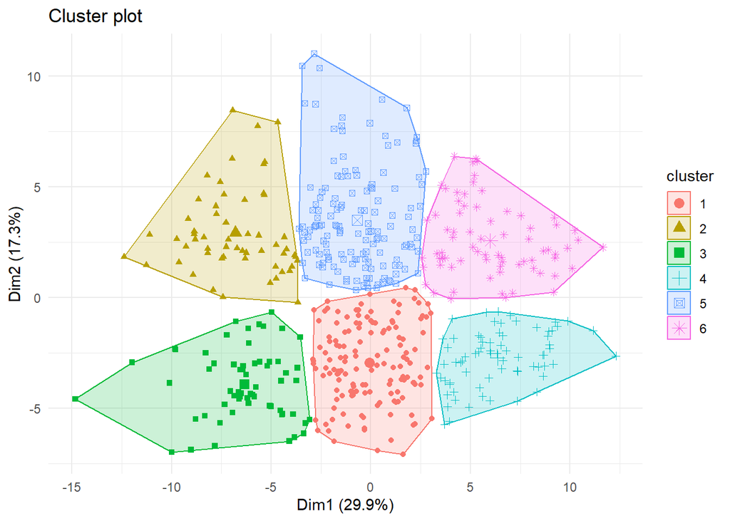

```r
# Choose a feature selection method
selected_features <- feature_selection_all(data)
# selected_features <- feature_selection_hand(data)
# selected_features <- feature_selection_variance(data, variance_threshold = 1)

# selected_features <- feature_selection_lasso(data)

# Run PCA and K-Means
pca_dimensions <- 2
number_of_clusters <- 6
pca_kmeans_result <- run_pca_kmeans(selected_features, pca_dimensions, number_of_clusters)

# Create visualizations
plots <- visualizations(data, selected_features, pca_kmeans_result$pca_data, pca_kmeans_result$kmeans_result, color_palette)

# Display plots
plots$cluster_plot
```

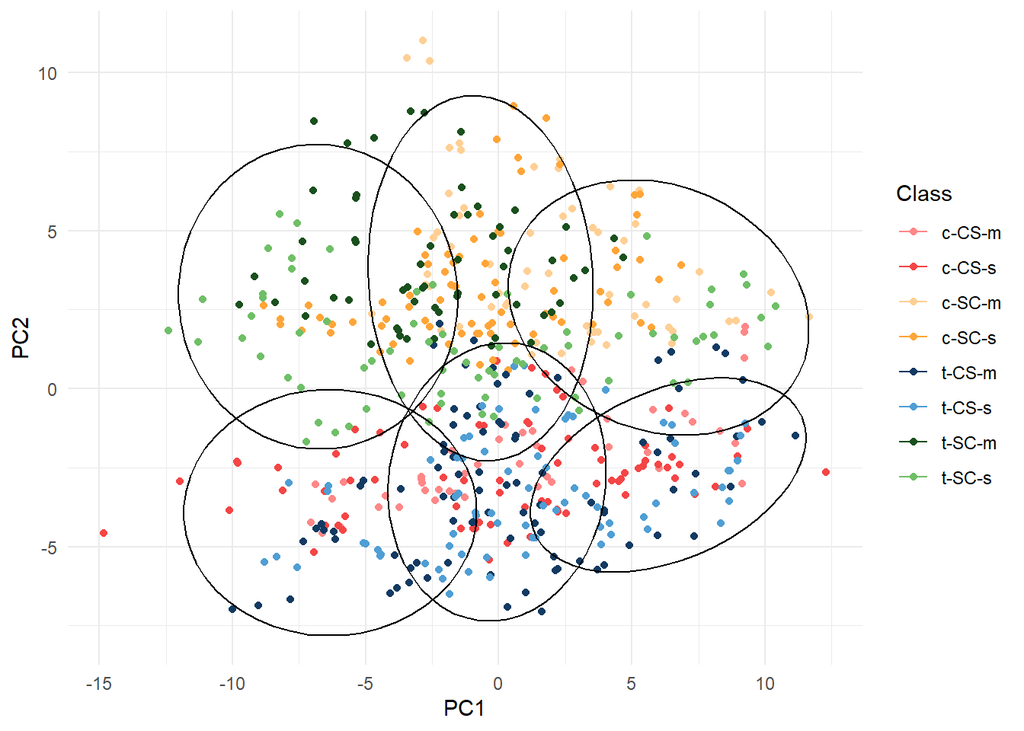

```r
plots$pca_plot
```

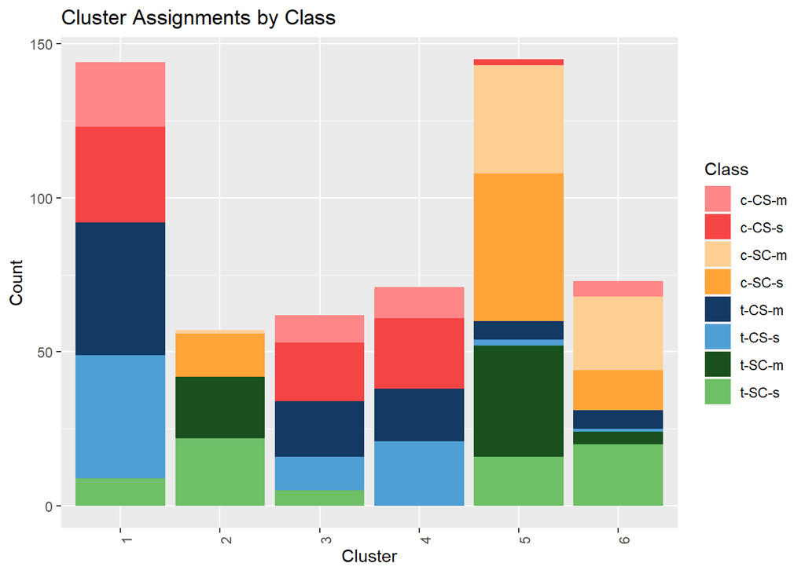

```r
plots$cluster_assignment_plot
```

### hand selection - 2 dim - 6 clusters

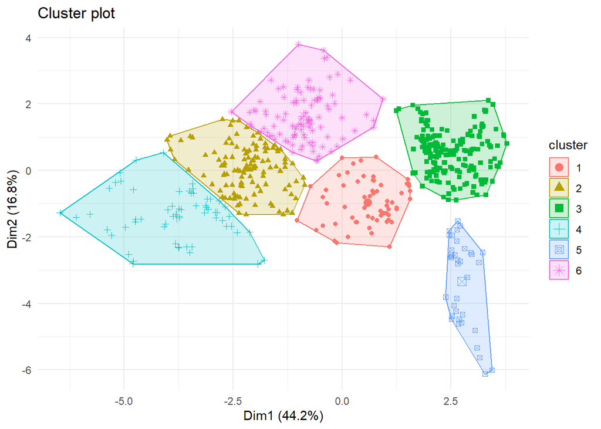

```r
# Choose a feature selection method
# selected_features <- feature_selection_all(data)
 selected_features <- feature_selection_hand(data)
# selected_features <- feature_selection_variance(data, variance_threshold = 1)
# selected_features <- feature_selection_rfe(data)
# selected_features <- feature_selection_lasso(data)

# Run PCA and K-Means
pca_dimensions <- 2
number_of_clusters <- 6
pca_kmeans_result <- run_pca_kmeans(selected_features, pca_dimensions, number_of_clusters)

# Create visualizations
plots <- visualizations(data, selected_features, pca_kmeans_result$pca_data, pca_kmeans_result$kmeans_result, color_palette)

# Display plots
plots$cluster_plot
```

```r
plots$pca_plot
```

[output not shown]

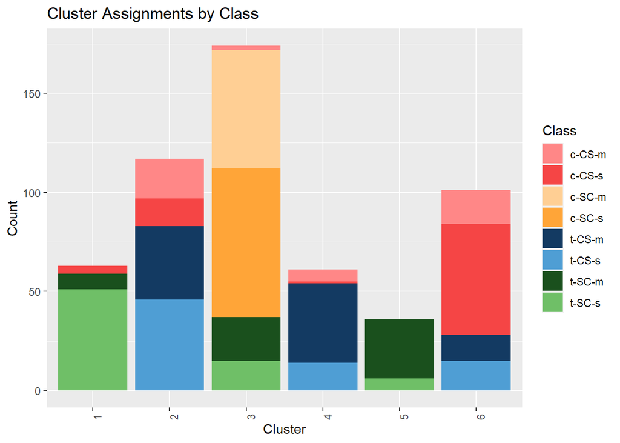

```r
plots$cluster_assignment_plot
```

### variance - 2 dim - 6 clusters

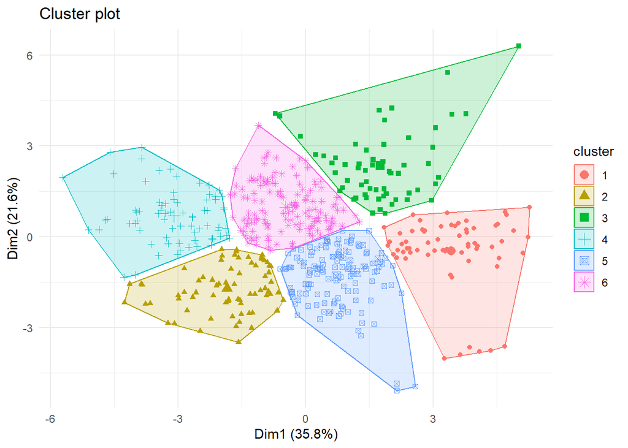

```r
# Choose a feature selection method
# selected_features <- feature_selection_all(data)
# selected_features <- feature_selection_hand(data)
 selected_features <- feature_selection_variance(data, variance_threshold = 1)
# selected_features <- feature_selection_rfe(data)
# selected_features <- feature_selection_lasso(data)

# Run PCA and K-Means
pca_dimensions <- 2
number_of_clusters <- 6
pca_kmeans_result <- run_pca_kmeans(selected_features, pca_dimensions, number_of_clusters)

# Create visualizations
plots <- visualizations(data, selected_features, pca_kmeans_result$pca_data, pca_kmeans_result$kmeans_result, color_palette)

# Display plots
plots$cluster_plot
```

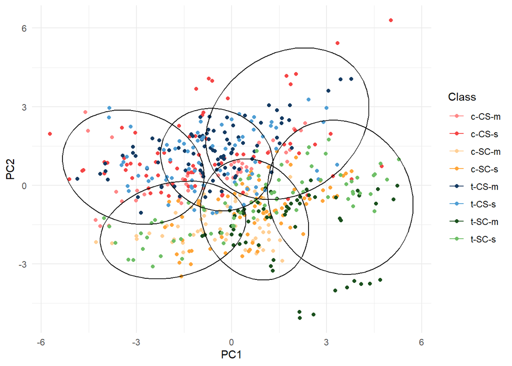

```r
plots$pca_plot
```

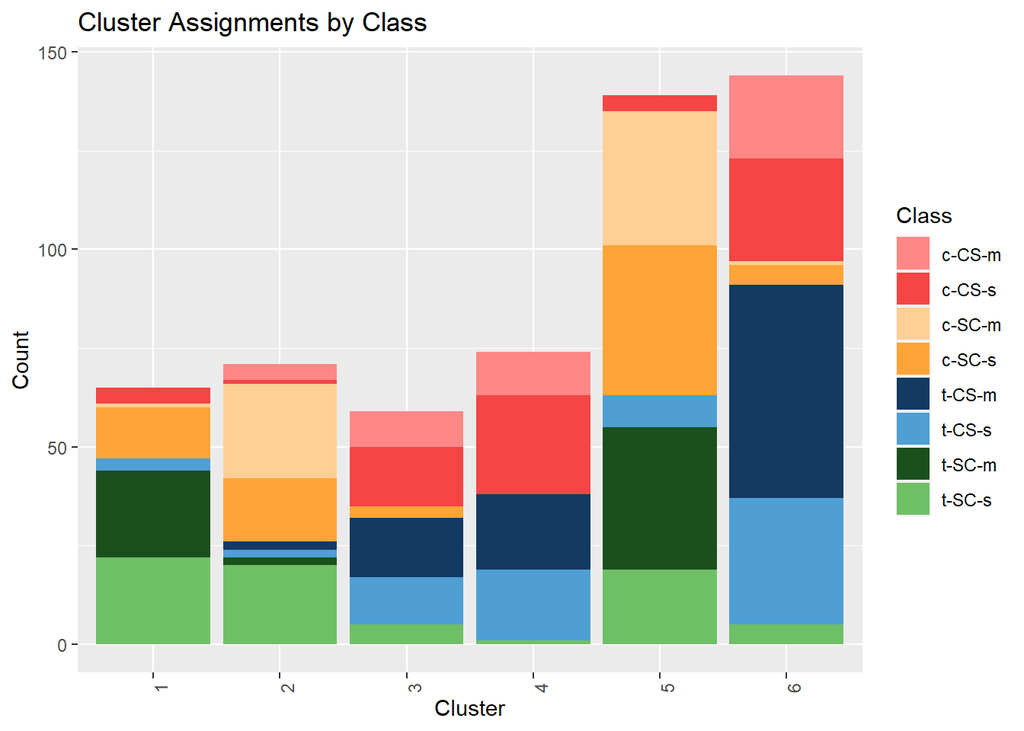

```r
plots$cluster_assignment_plot
```

### lasso - 2 dim - 6 clusters

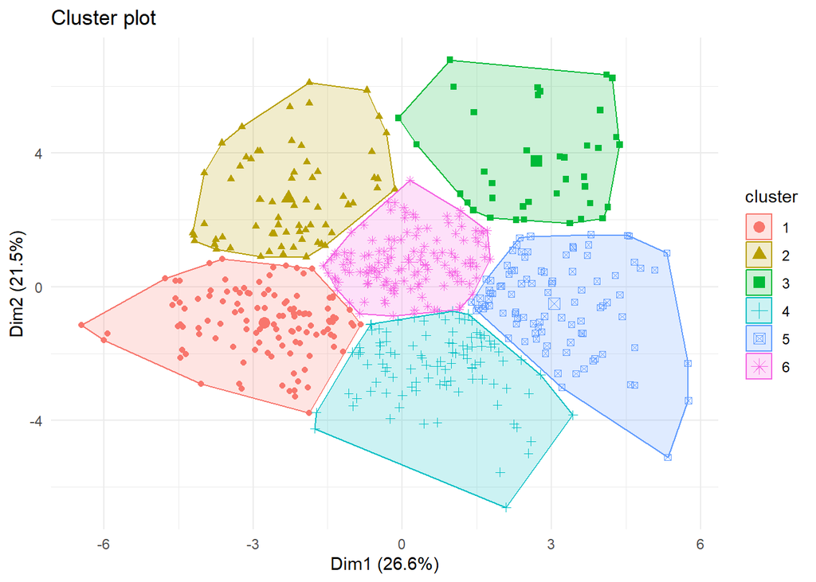

```r
# Choose a feature selection method
# selected_features <- feature_selection_all(data)
# selected_features <- feature_selection_hand(data)
# selected_features <- feature_selection_variance(data, variance_threshold = 1)
 selected_features <- feature_selection_lasso(data)

# Run PCA and K-Means
pca_dimensions <- 2
number_of_clusters <- 6
pca_kmeans_result <- run_pca_kmeans(selected_features, pca_dimensions, number_of_clusters)

# Create visualizations
plots <- visualizations(data, selected_features, pca_kmeans_result$pca_data, pca_kmeans_result$kmeans_result, color_palette)

# Display plots
plots$cluster_plot
```

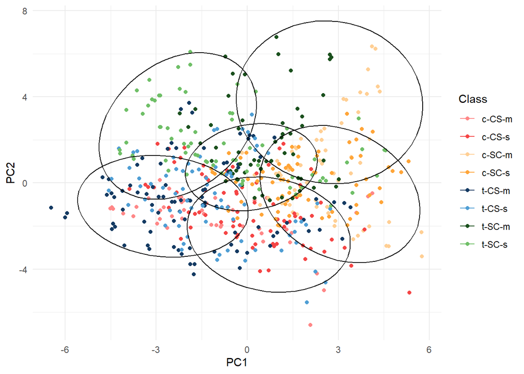

```r
plots$pca_plot
```

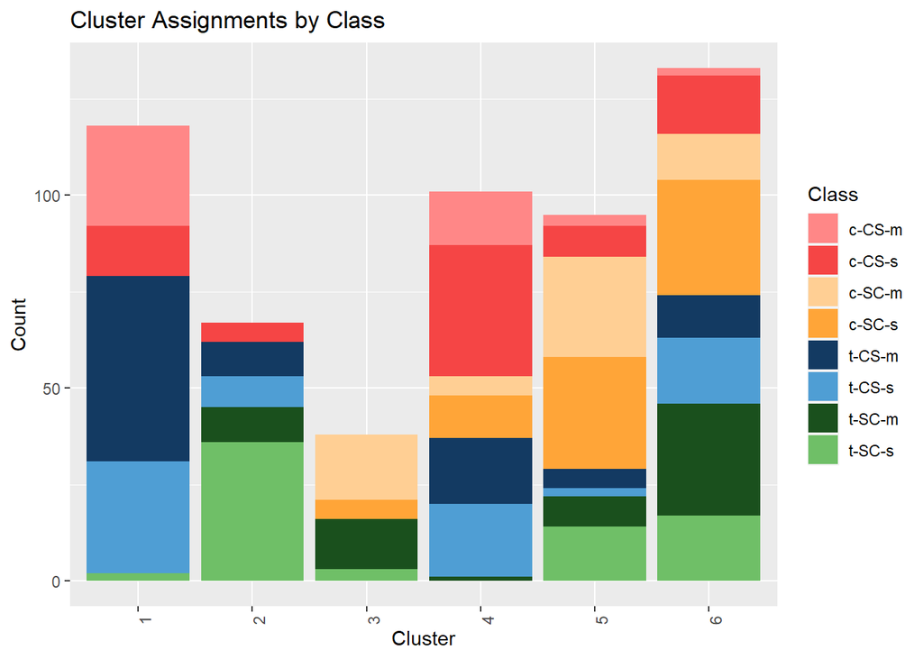

```r
plots$cluster_assignment_plot
```

## PCA # of dimensions

### PCA graphs

- **Scree Plot**: Look for the elbow point where the plot starts to flatten out. This point often indicates the number of components to retain.
- **Cumulative Proportion of Variance Explained**: Choose the number of components that explain a satisfactory level of the total variance, like 80% or 90%.
- **Kaiser Criterion**: Retain components with eigenvalues greater than 1.

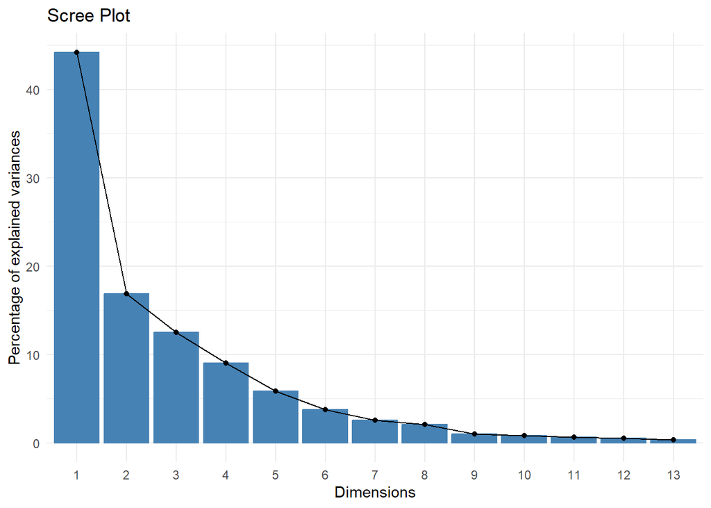

```r
selected_features <- feature_selection_hand(data)

# Perform PCA
pca_result <- prcomp(selected_features, center = TRUE, scale. = TRUE)

# Scree plot
library(factoextra)
fviz_screeplot(pca_result, ncp = 30) + theme_minimal() +
  ggtitle("Scree Plot")
```

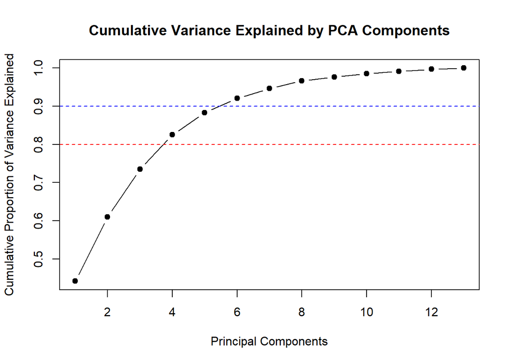

```r
# Calculate the cumulative variance explained
summary_pca <- summary(pca_result)
cumulative_variance <- cumsum(summary_pca$importance[2,])

# Plot cumulative variance
plot(cumulative_variance, xlab = "Principal Components", ylab = "Cumulative Proportion of Variance Explained", type = "b", pch = 19,
     main = "Cumulative Variance Explained by PCA Components")
abline(h = 0.8, col = "red", lty = 2)  # Line at 80% cumulative variance
abline(h = 0.9, col = "blue", lty = 2)  # Line at 90% cumulative variance
```

```r
# Kaiser Criterion
eigenvalues <- pca_result$sdev^2
kaiser_criterion <- sum(eigenvalues > 1)

# Display number of principal components with eigenvalues > 1
kaiser_criterion
```

```
[1] 4
```

### hand selection - 2 dim - 6 clusters

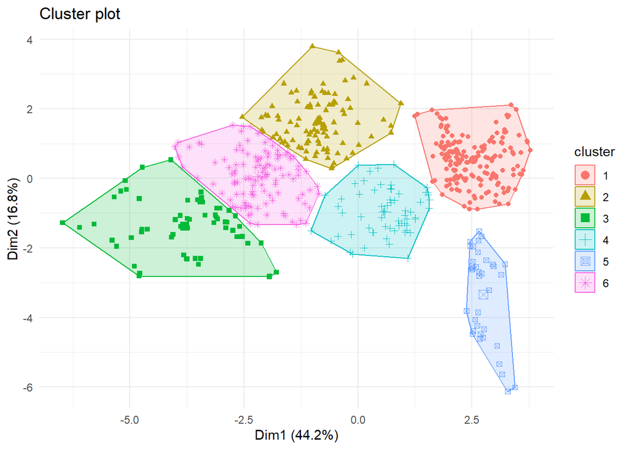

```r
# Choose a feature selection method
# selected_features <- feature_selection_all(data)
 selected_features <- feature_selection_hand(data)
# selected_features <- feature_selection_variance(data, variance_threshold = 1)
# selected_features <- feature_selection_rfe(data)
# selected_features <- feature_selection_lasso(data)

# Run PCA and K-Means
pca_dimensions <- 2
number_of_clusters <- 6
pca_kmeans_result <- run_pca_kmeans(selected_features, pca_dimensions, number_of_clusters)

# Create visualizations
plots <- visualizations(data, selected_features, pca_kmeans_result$pca_data, pca_kmeans_result$kmeans_result, color_palette)

# Display plots
plots$cluster_plot
```

```r
plots$pca_plot
```

[output not shown]

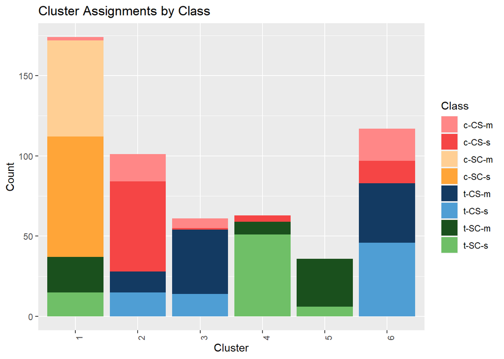

```r
plots$cluster_assignment_plot
```

### hand selection - 3 dim - 6 clusters

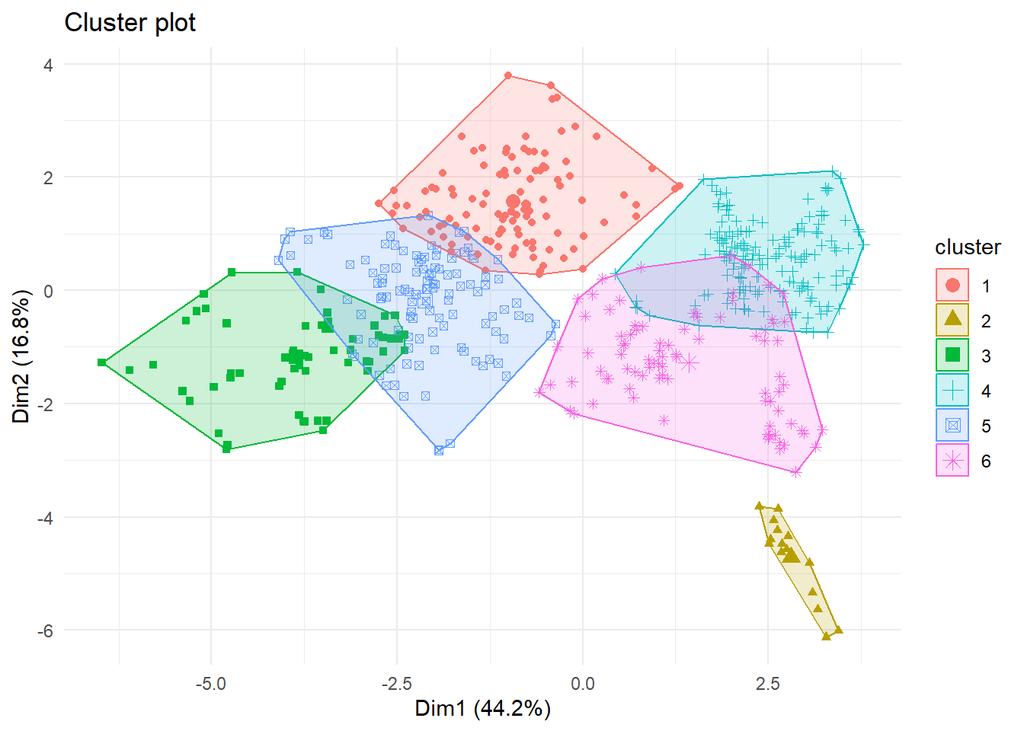

```r
# Choose a feature selection method
# selected_features <- feature_selection_all(data)
 selected_features <- feature_selection_hand(data)
# selected_features <- feature_selection_variance(data, variance_threshold = 1)
# selected_features <- feature_selection_rfe(data)
# selected_features <- feature_selection_lasso(data)

# Run PCA and K-Means
pca_dimensions <- 3
number_of_clusters <- 6
pca_kmeans_result <- run_pca_kmeans(selected_features, pca_dimensions, number_of_clusters)

# Create visualizations
plots <- visualizations(data, selected_features, pca_kmeans_result$pca_data, pca_kmeans_result$kmeans_result, color_palette)

# Display plots
plots$cluster_plot
```

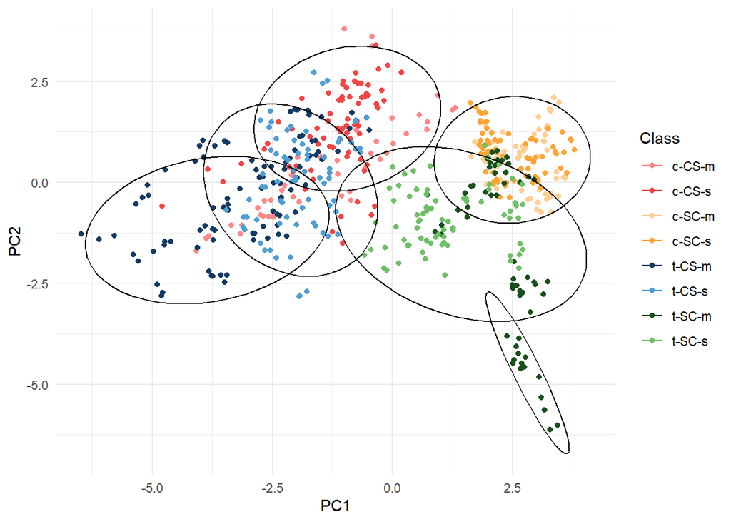

```r
plots$pca_plot
```

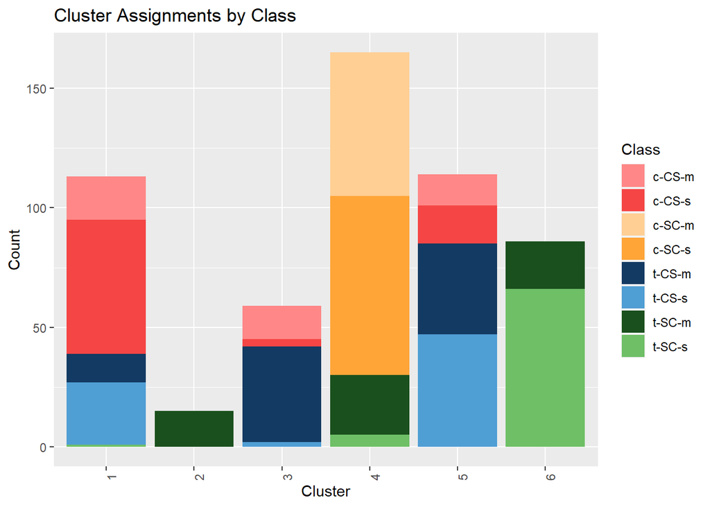

```r
plots$cluster_assignment_plot
```

### hand selection - 4 dim - 6 clusters

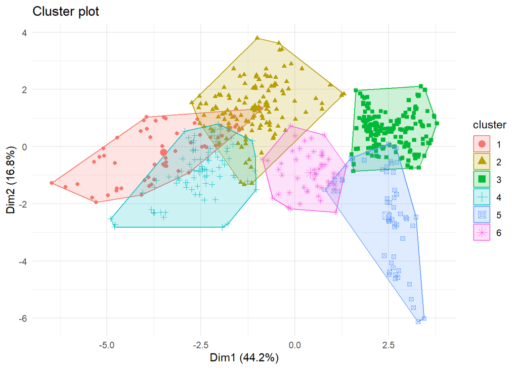

```r
# Choose a feature selection method
# selected_features <- feature_selection_all(data)
 selected_features <- feature_selection_hand(data)
# selected_features <- feature_selection_variance(data, variance_threshold = 1)
# selected_features <- feature_selection_rfe(data)
# selected_features <- feature_selection_lasso(data)

# Run PCA and K-Means
pca_dimensions <- 4
number_of_clusters <- 6
pca_kmeans_result <- run_pca_kmeans(selected_features, pca_dimensions, number_of_clusters)

# Create visualizations
plots <- visualizations(data, selected_features, pca_kmeans_result$pca_data, pca_kmeans_result$kmeans_result, color_palette)

# Display plots
plots$cluster_plot
```

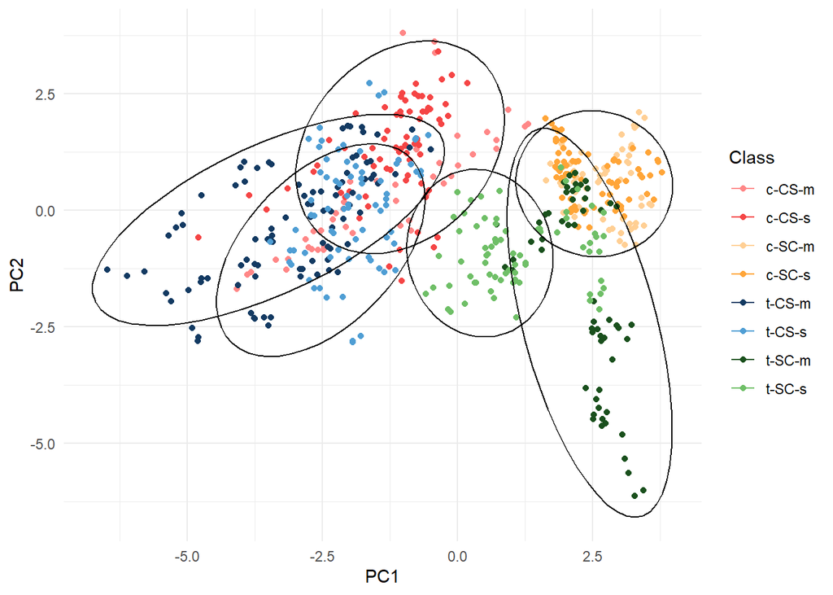

```r
plots$pca_plot
```

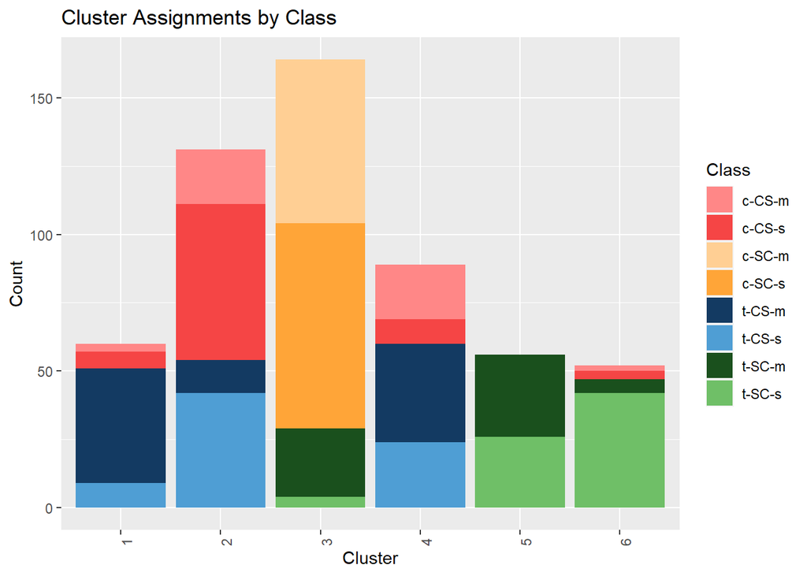

```r
plots$cluster_assignment_plot
```

### hand selection - 6 dim - 6 clusters

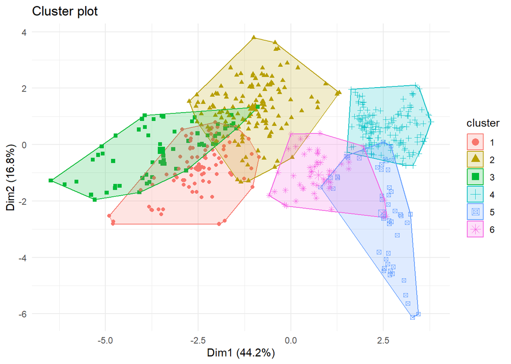

```r
# Choose a feature selection method
# selected_features <- feature_selection_all(data)
 selected_features <- feature_selection_hand(data)
# selected_features <- feature_selection_variance(data, variance_threshold = 1)
# selected_features <- feature_selection_rfe(data)
# selected_features <- feature_selection_lasso(data)

# Run PCA and K-Means
pca_dimensions <- 6
number_of_clusters <- 6
pca_kmeans_result <- run_pca_kmeans(selected_features, pca_dimensions, number_of_clusters)

# Create visualizations
plots <- visualizations(data, selected_features, pca_kmeans_result$pca_data, pca_kmeans_result$kmeans_result, color_palette)

# Display plots
plots$cluster_plot
```

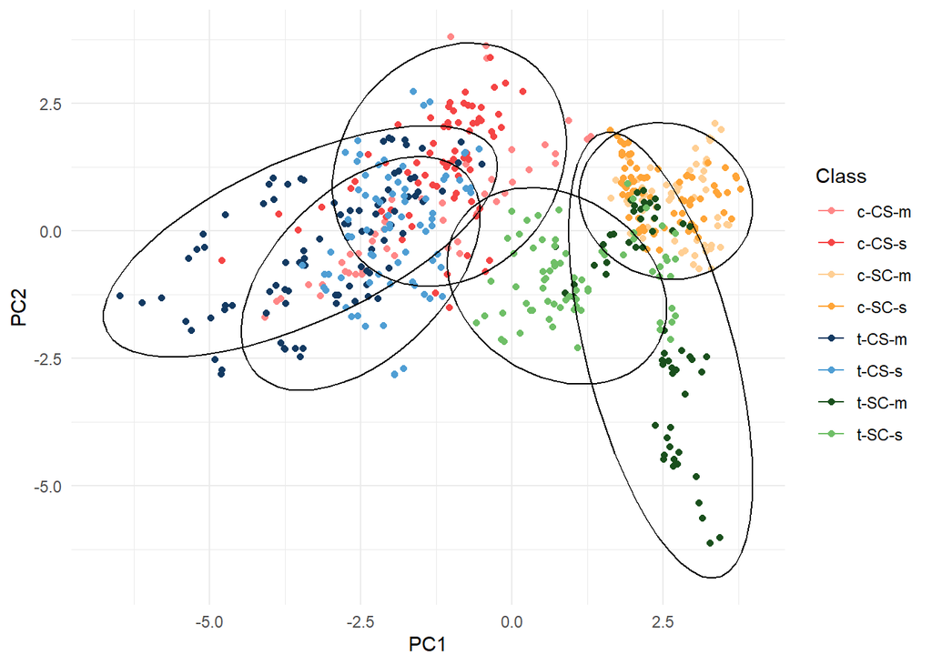

```r
plots$pca_plot
```

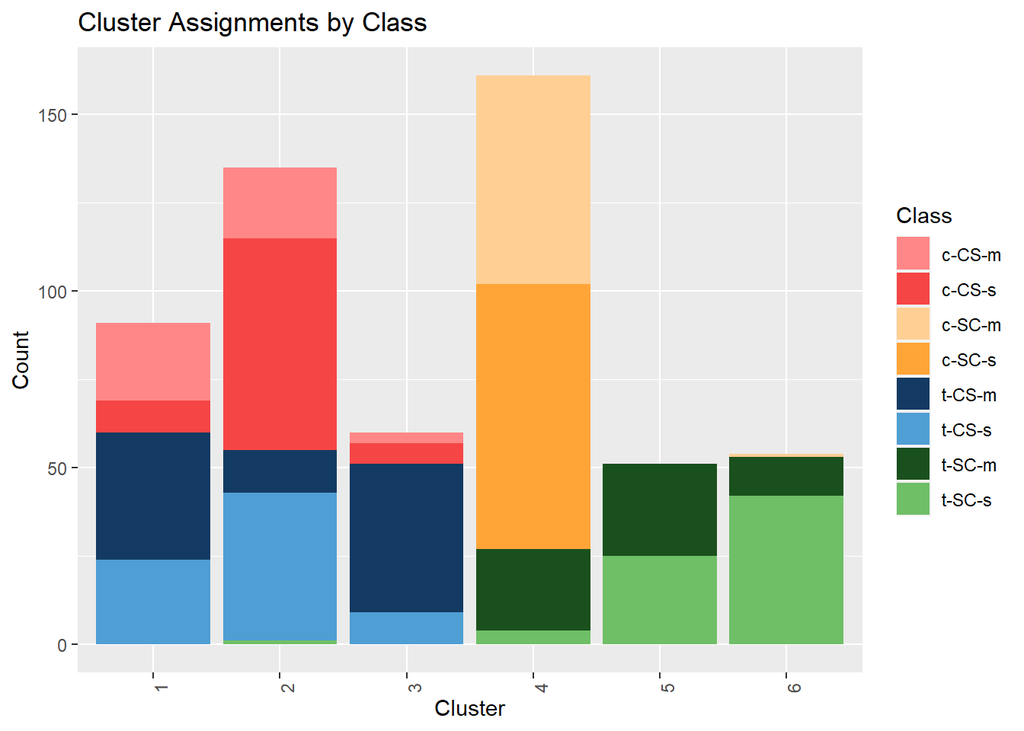

```r
plots$cluster_assignment_plot
```

### hand selection - 10 dim - 6 clusters

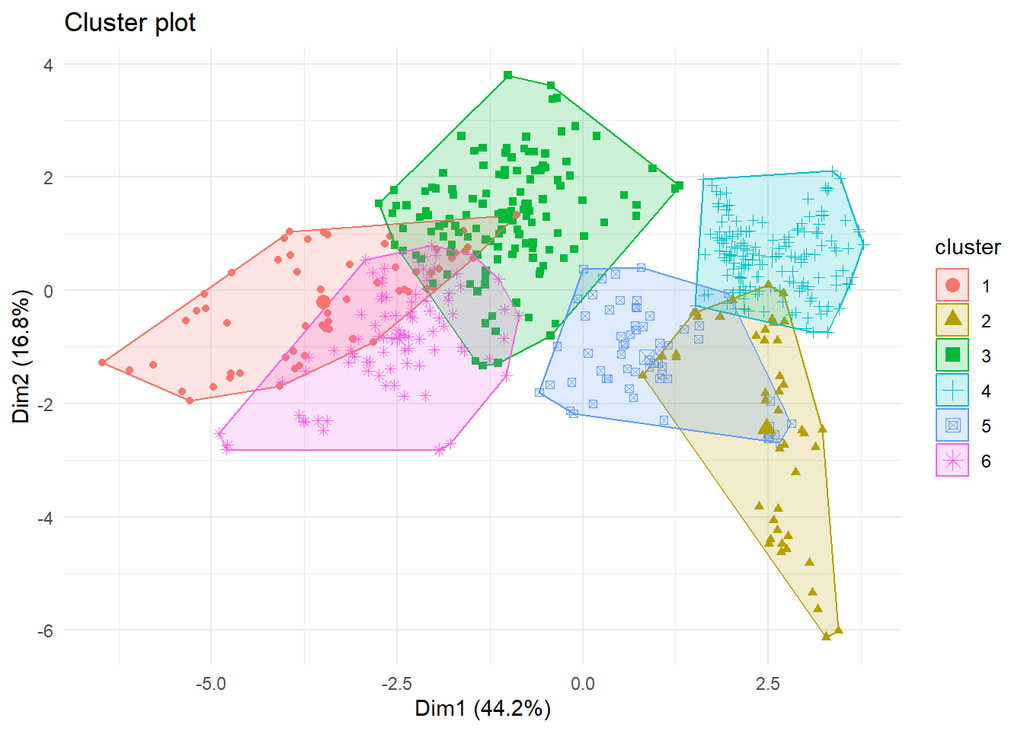

```r
# Choose a feature selection method
# selected_features <- feature_selection_all(data)
 selected_features <- feature_selection_hand(data)
# selected_features <- feature_selection_variance(data, variance_threshold = 1)
# selected_features <- feature_selection_rfe(data)
# selected_features <- feature_selection_lasso(data)

# Run PCA and K-Means
pca_dimensions <- 10
number_of_clusters <- 6
pca_kmeans_result <- run_pca_kmeans(selected_features, pca_dimensions, number_of_clusters)

# Create visualizations
plots <- visualizations(data, selected_features, pca_kmeans_result$pca_data, pca_kmeans_result$kmeans_result, color_palette)

# Display plots
plots$cluster_plot
```

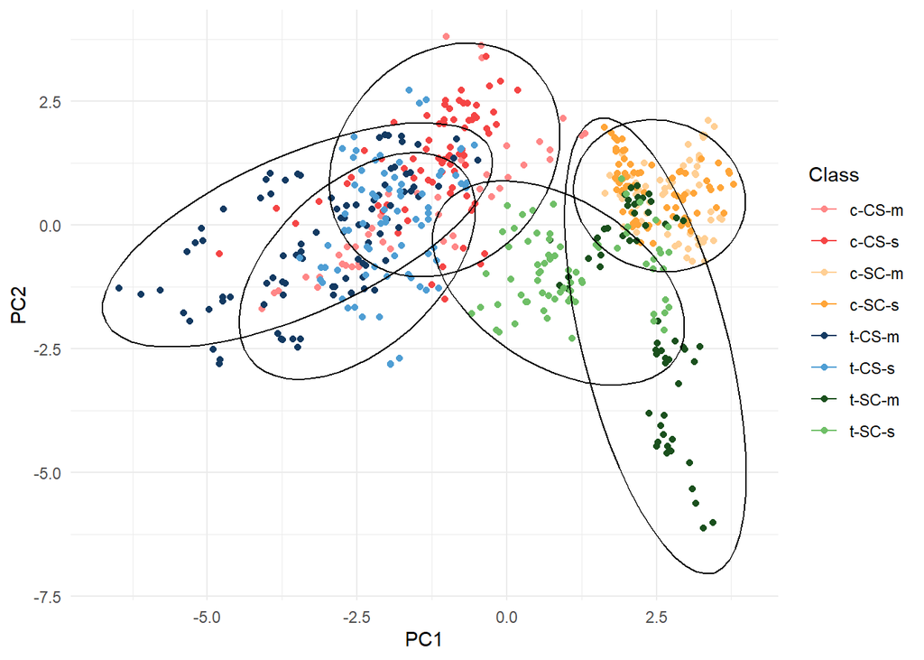

```r
plots$pca_plot
```

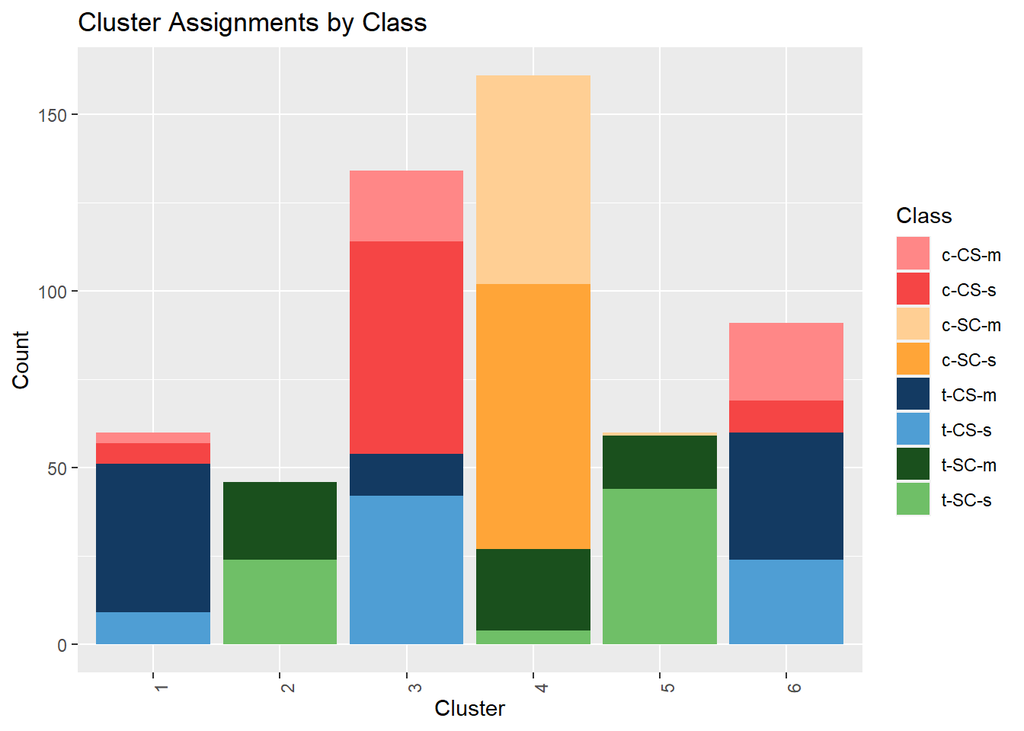

```r
plots$cluster_assignment_plot
```

## Number of clusters

### Study for # of clusters

- **Elbow Method**: Look for the “elbow point” where the WSS starts to slow down.
- **Silhouette Method**: Choose the number of clusters that maximize the average silhouette width.
- **Gap Statistic**: Select the number of clusters where the gap statistic is maximized.

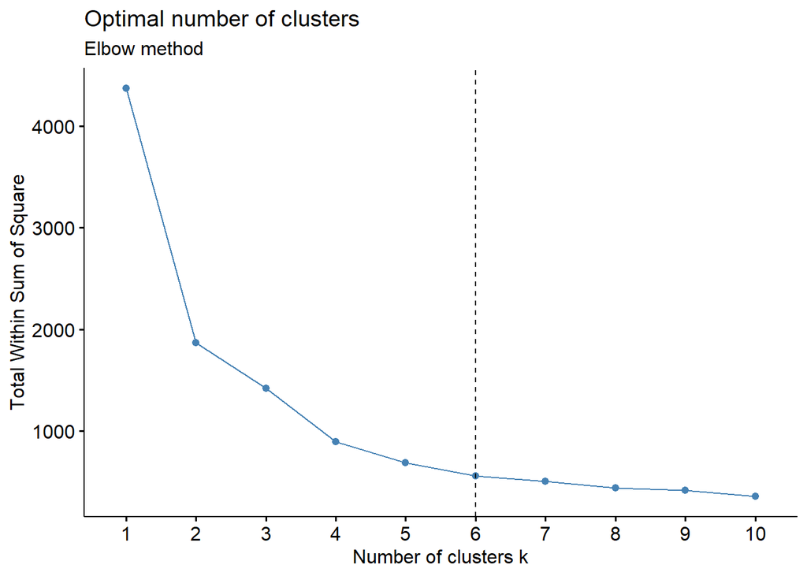

```r
selected_features <- feature_selection_hand(data)
pca_result <- prcomp(selected_features, center = TRUE, scale. = TRUE)
pca_data <- pca_result$x[, 1:2]

# Elbow Method
fviz_nbclust(pca_data, kmeans, method = "wss") +
  geom_vline(xintercept = 6, linetype = 2) +  # Adjust the xintercept based on actual elbow
  labs(subtitle = "Elbow method")
```

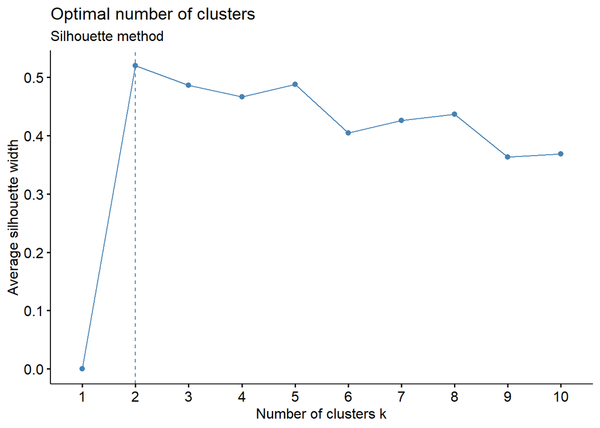

```r
# Silhouette Method
set.seed(123)
fviz_nbclust(pca_data, kmeans, method = "silhouette") +
  labs(subtitle = "Silhouette method")
```

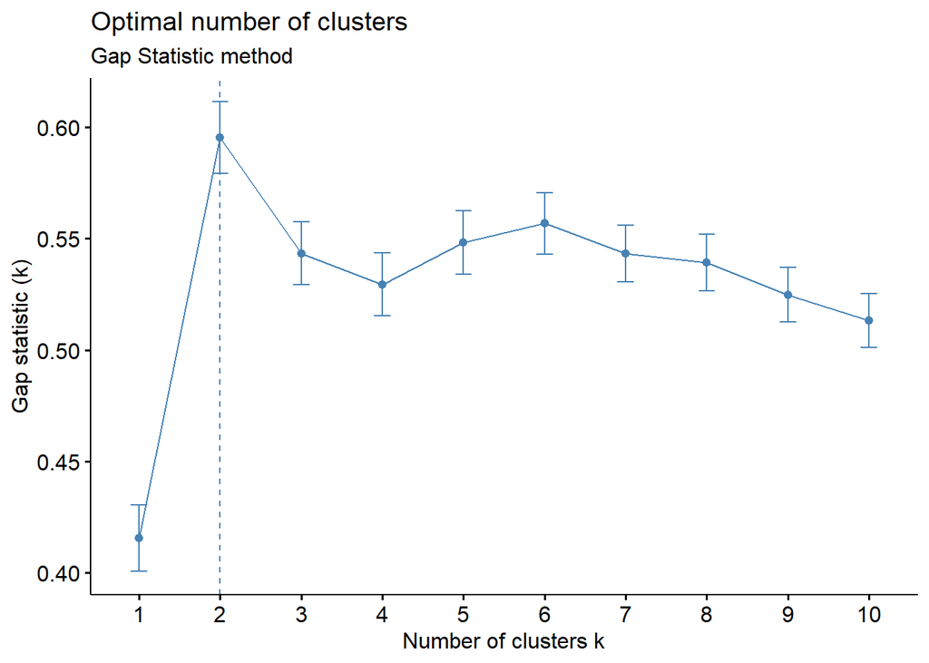

```r
# Gap Statistic Method
set.seed(123)
gap_stat <- clusGap(pca_data, FUN = kmeans, nstart = 25, K.max = 10, B = 50)
fviz_gap_stat(gap_stat) +
  labs(subtitle = "Gap Statistic method")
```